# Predicting Depression in Florida

## Using Machine Learning to Fill in Missing Data

SimplyAnalytics is a web-based data mapping application that incorporates information from several nationally representative data sources on a variety of subjects. One such source is the CDC PLACES project, primarily concerned with health outcomes (https://www.cdc.gov/places/index.html). Unfortunately, the CDC's data on rates of depression is missing for all counties in Florida. In this notebook, I attempt to predict what those depression rates are using machine learning.

I use various machine learning models to generate predictions of what this missing data is likely to be, based on the abundance of recorded data on other measures I deemed relevant to rates of depression in the US. The important thing to note is that data for depression is missing in Florida, but is recorded for every other state's counties. Additionally, both Florida and the other states' counties share the explanatory variables I have selected for this series of analyses. Because of this commonality, I can train the models using data from counties that have both the explanatory variables *and* data on depressive rates, so that I can apply it later to counties that have just the explanatory variables, and *not* data on depressive rates.

Please look below for my code.

```python
import warnings
warnings.filterwarnings("ignore", message="X does not have valid feature names")
```

```python
#Backbone of data organization
import pandas as pd
import numpy as np
#Machine learning tools from SciKit-Learn
from sklearn.linear_model import LogisticRegression, LinearRegression
from sklearn.discriminant_analysis import LinearDiscriminantAnalysis
from sklearn import metrics
from sklearn.naive_bayes import GaussianNB
from sklearn.metrics import confusion_matrix, classification_report, precision_score, get_scorer_names, mean_squared_error, r2_score, mean_squared_error, roc_auc_score, ConfusionMatrixDisplay, accuracy_score, f1_score, recall_score
from sklearn.model_selection import train_test_split, LeaveOneOut, cross_val_score, KFold, GridSearchCV, RandomizedSearchCV
from sklearn.inspection import DecisionBoundaryDisplay
from sklearn.neighbors import KNeighborsClassifier
from sklearn.tree import DecisionTreeRegressor, DecisionTreeClassifier, plot_tree, export_text
from sklearn.preprocessing import StandardScaler, PolynomialFeatures, SplineTransformer
from sklearn.feature_selection import SequentialFeatureSelector
from sklearn.ensemble import VotingClassifier, BaggingRegressor, BaggingClassifier, RandomForestRegressor, RandomForestClassifier, AdaBoostClassifier, AdaBoostRegressor, GradientBoostingRegressor, GradientBoostingClassifier
from sklearn.svm import LinearSVC, SVC
#Statistical Testing
from scipy import stats
#Visualization tools
import ipywidgets as widgets
from ipywidgets import interact
import seaborn as sns
import matplotlib.pyplot as plt
import plotly.graph_objects as go
import plotly.express as px
from plotly.subplots import make_subplots
import plotly.io as pio
pio.renderers.default = 'iframe'
#Helps keep track of training times
import time
```

## Preparing the data for classification

From SimplyAnalytics, I downloaded data on various explanatory variables in Shapefile format, before putting them through ArcGIS online to export them as .csv files. These were then joined together to create my datasets. As to not risk infringing on SimplyAnalytics' policies, I do not include the data I used with this repository, but one can find the data that I used with their own SimplyAnalytics account and the codebook I have included. To do this, export each of the variables I have specified in the codebook at the US county level, rename them to the variable names I used for my analysis, and join them together on the counties' spatial IDs.

Analyzedata.csv contains all of the data I utilized in my analysis. Depression itself is recorded via the "% population, with depression" column. The CDC PLACES website lists a more detailed explanation of this value (https://www.cdc.gov/places/measure-definitions/health-outcomes/index.html#depression). They record depression as the percentage of adults aged 18 or more years in the county who had ever reported a kind of depressive disorder to a healthcare provider.

There are some limitations to this variable; this data does not, for instance, discriminate between major and minor depression. This means that regardless of the intensity, peoples' depressive symptoms are counted equally. Additionally, even if one is not depresssed *now*, if they told a healthcare provider they were depressed at any point in their life, they are treated as part of this statistic. This means that some of the data may not reflect current trends in nation-wide depressive rates. Still, this variable should capture a suitable estimate of the scope of depression in the US.

```python
analyzedata = pd.read_csv("analyzedata.csv")
```

```python
analyzedata.head()
```

|  | Unnamed: 0 | spatial_id | name | perc_population_lacking_health_insurance | perc_population_noncitizens | perc_population_without_internet_access | perc_population_without_highschool_education | perc_population_whose_commute_is_90_minutes | Median_income | perc_population_male | ... | perc_population_cognitive_disability | perc_population_individual_living_disability | average_selfreported_mental_health | average_selfreported_physical_health | perc_population_binge_drinking | perc_population_smoking | perc_population_without_physical_activity | perc_population_less_than_7_hours_of_sleep | perc_population_in_poverty | perc_population_with_depression |
| --- | --- | --- | --- | --- | --- | --- | --- | --- | --- | --- | --- | --- | --- | --- | --- | --- | --- | --- | --- | --- | --- |
| 0 | 0 | 51610 | Falls Church city, VA | 3.8285 | 4.2811 | 1.6937 | 3.6473 | 1.3051 | 158005.583721 | 49.0126 | ... | 7.1765 | 3.7250 | 11.5805 | 6.9313 | 18.4176 | 7.9498 | 13.5138 | 30.2433 | 2.0871 | 19.8510 |
| 1 | 1 | 51678 | Lexington city, VA | 7.6005 | 3.3659 | 6.0019 | 4.5010 | 0.7884 | 63925.395035 | 60.4235 | ... | 15.8981 | 8.1917 | 19.5995 | 9.9059 | 19.0079 | 12.5000 | 21.1924 | 30.8101 | 26.2336 | 24.5904 |
| 2 | 2 | 72033 | Cataño Municipio, PR | 0.0000 | 0.0000 | 52.0332 | 24.0707 | 5.0907 | 19630.975519 | 46.9006 | ... | 0.0000 | 0.0000 | 0.0000 | 0.0000 | 0.0000 | 0.0000 | 0.0000 | 0.0000 | 45.0673 | 0.0000 |
| 3 | 3 | 51685 | Manassas Park city, VA | 12.1139 | 15.3833 | 4.0519 | 24.1794 | 10.5785 | 90256.312061 | 51.6286 | ... | 13.2299 | 6.5991 | 16.4425 | 9.7563 | 18.7213 | 15.1132 | 23.1366 | 35.5040 | 2.8343 | 20.9052 |
| 4 | 4 | 51580 | Covington city, VA | 8.4537 | 0.0351 | 3.2832 | 11.8706 | 1.4455 | 42783.823622 | 45.1805 | ... | 14.7383 | 9.3237 | 17.0748 | 13.5251 | 15.2101 | 19.3440 | 27.4994 | 35.5650 | 12.9587 | 23.4779 |

5 rows × 37 columns

The analyzedata dataset is split into two kinds - miss_data, which records information for the counties in FL (and Puerto Rico, which also has no information on depressive rates but does not have recorded values for most other explanatory variables), and precomp_data, which records information for all the other counties, and which will be used for training and testing the models.

```python
miss_data = analyzedata[analyzedata['perc_population_with_depression'] == 0]
```

```python
precomp_data = analyzedata[analyzedata['perc_population_with_depression'] != 0]
```

With precomp_data I can do some basic exploration of depression in the US before I start the analysis. Sorting the data by depressive rates, Honolulu County, Hawaii is the single least depressed county in the US (12.03%), followed by several Hawaiian counties and Prince George's County in Maryland. Additionally, Magoffin County, Kentucky is the single most depressed county in the US (33.20%), followed by several other Kentucky counties.

```python
(precomp_data.sort_values(by='perc_population_with_depression', ascending = True)).head()
```

|  | Unnamed: 0 | spatial_id | name | perc_population_lacking_health_insurance | perc_population_noncitizens | perc_population_without_internet_access | perc_population_without_highschool_education | perc_population_whose_commute_is_90_minutes | Median_income | perc_population_male | ... | perc_population_cognitive_disability | perc_population_individual_living_disability | average_selfreported_mental_health | average_selfreported_physical_health | perc_population_binge_drinking | perc_population_smoking | perc_population_without_physical_activity | perc_population_less_than_7_hours_of_sleep | perc_population_in_poverty | perc_population_with_depression |
| --- | --- | --- | --- | --- | --- | --- | --- | --- | --- | --- | --- | --- | --- | --- | --- | --- | --- | --- | --- | --- | --- |
| 3148 | 3148 | 15003 | Honolulu County, HI | 5.2956 | 7.2010 | 5.6249 | 8.1999 | 2.6695 | 92824.581663 | 50.5588 | ... | 9.3545 | 5.2851 | 12.8306 | 8.1250 | 17.2830 | 11.0493 | 20.6669 | 41.6486 | 8.6468 | 12.0295 |
| 70 | 70 | 15005 | Kalawao County, HI | 5.5556 | 0.3906 | 0.0000 | 0.7752 | 0.0000 | 81665.653931 | 59.3750 | ... | 10.7692 | 7.6923 | 12.3077 | 9.2308 | 16.9231 | 13.8462 | 21.5385 | 36.9231 | 1.9841 | 12.3077 |
| 3086 | 3086 | 15009 | Maui County, HI | 6.2804 | 8.1524 | 7.3821 | 9.0461 | 1.4498 | 89603.826535 | 49.8382 | ... | 10.4216 | 5.8887 | 13.1815 | 8.2612 | 18.3690 | 12.9121 | 18.8404 | 35.7029 | 9.0900 | 13.0596 |
| 2010 | 2010 | 24033 | Prince George's County, MD | 11.7676 | 13.2117 | 3.9966 | 13.8406 | 4.1999 | 91744.863839 | 48.2978 | ... | 11.4939 | 6.8346 | 14.1653 | 9.0093 | 12.5228 | 11.4578 | 23.3100 | 40.3515 | 9.2147 | 13.1289 |
| 2594 | 2594 | 15007 | Kauai County, HI | 6.0408 | 7.8048 | 4.7208 | 9.0390 | 0.5492 | 88415.786691 | 49.7258 | ... | 10.3278 | 6.0378 | 13.2342 | 9.5351 | 17.3332 | 12.8307 | 20.4056 | 38.2744 | 8.5223 | 13.8287 |

5 rows × 37 columns

```python
(precomp_data.sort_values(by='perc_population_with_depression', ascending = False)).head()
```

|  | Unnamed: 0 | spatial_id | name | perc_population_lacking_health_insurance | perc_population_noncitizens | perc_population_without_internet_access | perc_population_without_highschool_education | perc_population_whose_commute_is_90_minutes | Median_income | perc_population_male | ... | perc_population_cognitive_disability | perc_population_individual_living_disability | average_selfreported_mental_health | average_selfreported_physical_health | perc_population_binge_drinking | perc_population_smoking | perc_population_without_physical_activity | perc_population_less_than_7_hours_of_sleep | perc_population_in_poverty | perc_population_with_depression |
| --- | --- | --- | --- | --- | --- | --- | --- | --- | --- | --- | --- | --- | --- | --- | --- | --- | --- | --- | --- | --- | --- |
| 1151 | 1151 | 21153 | Magoffin County, KY | 10.8973 | 0.6770 | 18.3244 | 29.3527 | 8.6843 | 28278.600000 | 50.0391 | ... | 24.7120 | 14.5200 | 22.4909 | 19.2631 | 13.1707 | 30.8251 | 38.7234 | 40.0519 | 29.5216 | 33.2019 |
| 190 | 190 | 21129 | Lee County, KY | 12.6859 | 0.6922 | 18.3061 | 28.2597 | 18.3665 | 28848.907609 | 58.7194 | ... | 26.6484 | 16.2740 | 23.1233 | 21.0046 | 13.0594 | 33.4612 | 41.8265 | 41.2237 | 30.0706 | 32.3653 |
| 1917 | 1917 | 21205 | Rowan County, KY | 8.2695 | 0.7073 | 5.8783 | 13.5629 | 3.6119 | 45760.072048 | 47.9568 | ... | 22.4782 | 12.0390 | 22.5940 | 15.0123 | 14.6300 | 22.9914 | 30.4825 | 38.0792 | 26.4521 | 32.2433 |
| 1226 | 1226 | 21131 | Leslie County, KY | 11.0912 | 0.1171 | 7.5329 | 16.5167 | 7.0366 | 36659.224346 | 50.8883 | ... | 24.8793 | 15.0836 | 22.8731 | 20.0248 | 13.0526 | 30.9226 | 40.2353 | 41.1022 | 34.0897 | 31.9257 |
| 1632 | 1632 | 21051 | Clay County, KY | 13.3266 | 0.4504 | 21.7026 | 32.8616 | 3.2357 | 32320.219341 | 52.6453 | ... | 26.5801 | 15.8982 | 23.2358 | 20.2658 | 13.2651 | 33.4935 | 39.9763 | 42.5158 | 31.2620 | 31.8525 |

5 rows × 37 columns

Given the low predictive power of single variables, and challenges of utilizing multiple linear regression with a high number of independent variables, predicting an exact number for depression in Florida presents a challenging task. It would instead be easier to split the depression statistic into multiple percentile ranges, thereby treating depression as a categorical variable, so that tools such as logistic regression and linear discriminant analysis can be used. The goal being to generate a simple estimate of depression in these states, a categorical variable could perform just as well as a numerical variable. At any rate, the prediction is only meaningful when compared against the data for other counties, which this approach will accomplish.

The *quartileranges* function assesses what each of the categories I divide the depression data into actually mean. In this case, since I am splitting the data into quartiles, I have four classifications, for which the function shows us the ranges they correspond to. 'Q1' stands for the first quartile, or the category entailing the smallest rates of depression, and 'Q4' stands for the fourth quartile, entailing the highest rates of depression.

```python
def quartileranges(x):
    quartiles = []
    for i in range(1, x + 1):
        quartiles.append("Q" + str(i))
    comp_data = precomp_data.copy()
    comp_data['dep_qt'] = pd.qcut(precomp_data['perc_population_with_depression'], q=x, labels=quartiles)
    for i in quartiles:
        comp_databd = comp_data.query(f'dep_qt == "{i}"')
        print([i, comp_databd.perc_population_with_depression.min(), comp_databd.perc_population_with_depression.max()])
```

```python
quartileranges(4)
```

```
['Q1', 12.0295, 20.9249]
['Q2', 20.9275, 22.8042]
['Q3', 22.8045, 24.979]
['Q4', 24.9818, 33.2019]
```

The last step before the analysis is to create a new dataset, "comp_data", from precomp_data, with which I finalize the quartile split. I then separate the new dependent variable, dep_qt, which becomes "y," and drop unnecessary columns from comp_data, which becomes "X." These separate dataframes will be utilized for the train-test split function. Leaving 35% of the counties for testing purposes, I also standardize the independent variables in order to ensure each functions on a scale equivalent to one another in the models.

```python
comp_data = precomp_data.copy()
comp_data['dep_qt'] = pd.qcut(precomp_data['perc_population_with_depression'], q=4, labels=['Q1', 'Q2', 'Q3', 'Q4'])
```

```python
y = comp_data['dep_qt']
X = comp_data.drop(['Unnamed: 0', 'spatial_id', 'name', 'perc_population_with_depression', 'dep_qt'], axis=1)
```

```python
X_train, X_test, y_train, y_test = train_test_split(X, y, test_size=0.35, random_state=1)
```

```python
scaler = StandardScaler()
X_train_scaled = scaler.fit_transform(X_train)
X_train = pd.DataFrame(X_train_scaled, columns=X_train.columns)
X_test_scaled = scaler.transform(X_test)
X_test = pd.DataFrame(X_test_scaled, columns=X_test.columns)
```

## Logistic Regression

I can optimize the logistic regression in one of three ways based off of the different assignable penalties during hyperparameter tuning, those being l1, l2, and elasticnet, which uses both l1 and l2 penalties. Since these penalties are only compatible with certain solvers, I set each of the penalties as constant and use GridSearchCV to parse through the solvers and C values in three separate functions.

Comparing each penalty individually, the best performance for logistic regression comes from using an LBFGS solver and l2 penalty, with around 69% accuracy. This model, as does many others, does exceptionally well at predicting the most extreme quartiles, but not as well as predicting those in between, suffering roughly a 20% decrease in accuracy when predicting the second or third quartiles as opposed to predicting the first or fourth.

```python
# start = time.time()
# logreg = LogisticRegression(solver = 'liblinear', penalty = 'l1',  max_iter = 100000)
# param_grid = {'C': [0.01, 0.1, 1, 10, 100, 1000]}
# grid_search = GridSearchCV(logreg, param_grid, cv=5, scoring='accuracy')
# grid_search.fit(X_train, y_train)
# best_params = grid_search.best_params_
# print("Best Hyperparameters:", best_params)
# end = time.time()
# print(f"Time elapsed: {end-start:.4f}")
```

```python
# Starts timer
start = time.time()
# References specific model, establishes set hyperparameters
logreg = LogisticRegression(solver = 'newton-cg', penalty = 'l2',  max_iter = 100000)
# Outlines hyperparameters for GridSearchCV to find the optimal combination between
param_grid = {
    'C': [0.01, 0.1, 1, 10, 100, 1000],
    'solver': ['lbfgs', 'liblinear', 'newton-cg', 'newton-cholesky', 'sag']}
grid_search = GridSearchCV(logreg, param_grid, cv=5, scoring='accuracy')
# Finds, prints optimal combination
grid_search.fit(X_train, y_train)
best_params = grid_search.best_params_
print("Best Hyperparameters:", best_params)
# Ends timer
end = time.time()
# Provides total time needed to complete model
print(f"Time elapsed: {end-start:.4f}")
```

```
Best Hyperparameters: {'C': 1, 'solver': 'lbfgs'}
Time elapsed: 65.0526
```

```python
# start = time.time()
# logreg = LogisticRegression(solver = 'saga', penalty = 'elasticnet',  max_iter = 100000)
# param_grid = {
#             'C': [0.01, 0.1, 1, 10, 100, 1000],
#             'l1_ratio': [0.1, 0.5, 0.7, 0.9]
# }
# grid_search = GridSearchCV(logreg, param_grid, cv=5, scoring='accuracy')
# grid_search.fit(X_train, y_train)
# best_params = grid_search.best_params_
# print("Best Hyperparameters:", best_params)
# end = time.time()
# print(f"Time elapsed: {end-start:.4f}")
```

```
Accuracy: 0.6899
Precision: 0.6907
F1: 0.6903
Recall: 0.6899
```

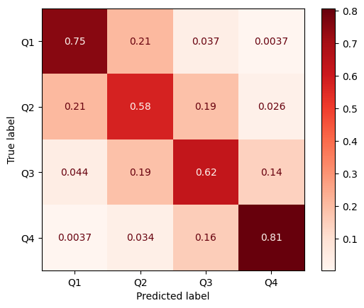

```
[[203  56  10   1]
 [ 56 154  50   7]
 [ 12  51 170  39]
 [  1   9  42 216]]
              precision    recall  f1-score   support

          Q1       0.75      0.75      0.75       270
          Q2       0.57      0.58      0.57       267
          Q3       0.62      0.62      0.62       272
          Q4       0.82      0.81      0.81       268

    accuracy                           0.69      1077
   macro avg       0.69      0.69      0.69      1077
weighted avg       0.69      0.69      0.69      1077
```

```python
# References model found by GridSearchCV
logregbm = grid_search.best_estimator_
# Loads in testing data
lr_y_pred = logregbm.predict(X_test)
# Assesses, prints accuracy of model's predictions to actual quartiles
logregacc = accuracy_score(y_test, lr_y_pred)
logregpre = precision_score(y_test, lr_y_pred, average='weighted')
logregf1 = f1_score(y_test, lr_y_pred, average='weighted')
logregrecall = recall_score(y_test, lr_y_pred, average='weighted')
print(f"Accuracy: {logregacc:.4f}")
print(f"Precision: {logregpre:.4f}")
print(f"F1: {logregf1:.4f}")
print(f"Recall: {logregrecall:.4f}")
# Creates confusion matrixes and classification report detailing strengths and weaknesses of models' predictions
ConfusionMatrixDisplay.from_estimator(logregbm, X_test, y_test, cmap = plt.cm.Reds, normalize = 'true')
plt.show()
print(confusion_matrix(y_test, lr_y_pred))
print(classification_report(y_test, lr_y_pred))
```

## Linear Discriminant Analysis

The Linear Discriminant Analysis (LDA) model does not do as well as the Logistic Regression, but only for predicting extreme quartiles. Performance for predicting the middle quartiles is rarer and more valuable, and in this regard the LDA performs roughly the same if not slightly better.

The LDA can be optimized by solver and by shrinkage. The SVD solver, which is the most accurate in this case, is not compatible with shrinkage, so a distinction is made in the code. This model has around 67% accuracy overall.

```python
start = time.time()
lda = LinearDiscriminantAnalysis()
param_grid = [
    {'solver': ['svd'], 'shrinkage': [None]},
    {'solver': ['lsqr', 'eigen'], 'shrinkage': ['auto', 0.1, 0.5, 0.9]}
]
grid_search = GridSearchCV(lda, param_grid, cv=5, scoring='accuracy')
grid_search.fit(X_train, y_train)
best_params = grid_search.best_params_
print("Best Hyperparameters:", best_params)
end = time.time()
print(f"Time elapsed: {end-start:.4f}")
```

```
Best Hyperparameters: {'shrinkage': None, 'solver': 'svd'}
Time elapsed: 3.0342
```

```
Accuracy: 0.6676
```

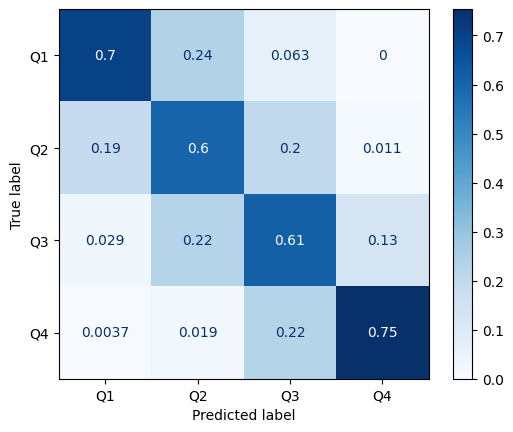

```
[[189  64  17   0]
 [ 50 161  53   3]
 [  8  61 167  36]
 [  1   5  60 202]]
              precision    recall  f1-score   support

          Q1       0.76      0.70      0.73       270
          Q2       0.55      0.60      0.58       267
          Q3       0.56      0.61      0.59       272
          Q4       0.84      0.75      0.79       268

    accuracy                           0.67      1077
   macro avg       0.68      0.67      0.67      1077
weighted avg       0.68      0.67      0.67      1077
```

```python
ldabm = grid_search.best_estimator_
lda_y_pred = ldabm.predict(X_test)
ldaacc = accuracy_score(lda_y_pred, y_test)
print(f"Accuracy: {ldaacc:.4f}")
ConfusionMatrixDisplay.from_estimator(ldabm, X_test, y_test, cmap = plt.cm.Blues, normalize = 'true')
plt.show()
print(confusion_matrix(y_test, lda_y_pred))
print(classification_report(y_test, lda_y_pred))
```

## Gaussian Naive Bayes

```
Accuracy: 0.4132
```

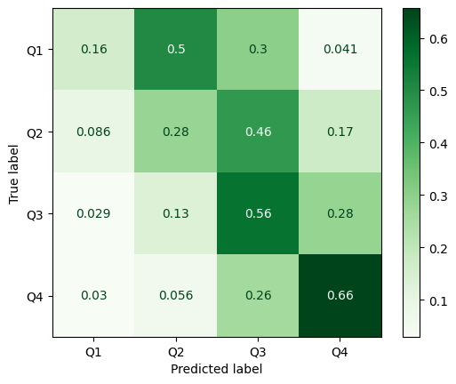

```
[[ 42 136  81  11]
 [ 23  75 124  45]
 [  8  35 152  77]
 [  8  15  69 176]]
              precision    recall  f1-score   support

          Q1       0.52      0.16      0.24       270
          Q2       0.29      0.28      0.28       267
          Q3       0.36      0.56      0.44       272
          Q4       0.57      0.66      0.61       268

    accuracy                           0.41      1077
   macro avg       0.43      0.41      0.39      1077
weighted avg       0.43      0.41      0.39      1077

Time elapsed: 0.4085
```

```python
start = time.time()
NBayes = GaussianNB()
NBayes.fit(X_train, y_train)
NB_y_pred = NBayes.predict(X_test)
NBayesacc = accuracy_score(NB_y_pred, y_test)
print(f"Accuracy: {NBayesacc:.4f}")
ConfusionMatrixDisplay.from_estimator(NBayes, X_test, y_test, cmap = plt.cm.Greens, normalize = 'true')
plt.show()
print(confusion_matrix(y_test, NB_y_pred))
print(classification_report(y_test, NB_y_pred))
end = time.time()
print(f"Time elapsed: {end-start:.4f}")
```

## K-Nearest Neighbors Classifier

Similarly to the Logisstic Regression and LDA models, this model does well at predicting extreme quartiles but suffers in middle quartiles. In this regard, it also has a reduced accuracy of around 60%.

```
The optimal K is: 57
```

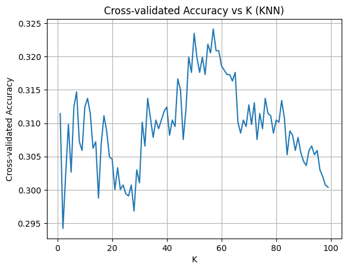

```python
# Finds optimal "K", or the number of nearby data points needed to classify another data point
def optknn(X, y):
    k_values = range(1, 100)
    cv_scores = []
    # Finds Cross-Validated Accuracy for models with Ks ranging from 1 to 100 given appropriate data
    for k in k_values:
        knn = KNeighborsClassifier(n_neighbors=k)
        scores = cross_val_score(knn, X, y, cv=4, scoring='accuracy')
        cv_scores.append(scores.mean())
    optimal_k = k_values[np.argmax(cv_scores)]
    print(f"The optimal K is: {optimal_k}")
    # Creates visualization between accuracy and K for 100 models built
    plt.plot(k_values, cv_scores)
    plt.xlabel('K')
    plt.ylabel('Cross-validated Accuracy')
    plt.title('Cross-validated Accuracy vs K (KNN)')
    plt.grid(True)
    plt.show()
optknn(X, y)
```

```
Cross-validation scores: [0.5975    0.52      0.565     0.5625    0.5112782]
Average cross-validation score: 0.5513
Accuracy: 0.6091
```

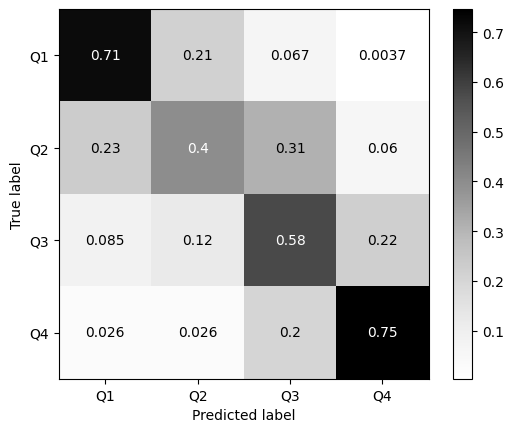

```
[[193  58  18   1]
 [ 62 106  83  16]
 [ 23  32 157  60]
 [  7   7  54 200]]
              precision    recall  f1-score   support

          Q1       0.68      0.71      0.70       270
          Q2       0.52      0.40      0.45       267
          Q3       0.50      0.58      0.54       272
          Q4       0.72      0.75      0.73       268

    accuracy                           0.61      1077
   macro avg       0.61      0.61      0.60      1077
weighted avg       0.61      0.61      0.60      1077

Time elapsed: 0.5556
```

```python
start = time.time()
knn = KNeighborsClassifier(n_neighbors=57)
cv_scores = cross_val_score(knn, X_train, y_train, cv=5)
print("Cross-validation scores:", cv_scores)
print(f"Average cross-validation score: {cv_scores.mean():.4f}", )
knn.fit(X_train, y_train)
knn_y_pred = knn.predict(X_test)
test_accuracy = accuracy_score(y_test, knn_y_pred)
knnacc = accuracy_score(knn_y_pred, y_test)
print(f"Accuracy: {knnacc:.4f}")
ConfusionMatrixDisplay.from_estimator(knn, X_test, y_test, cmap = plt.cm.Greys, normalize = 'true')
plt.show()
print(confusion_matrix(y_test, knn_y_pred))
print(classification_report(y_test, knn_y_pred))
end = time.time()
print(f"Time elapsed: {end-start:.4f}")
```

## Support Vector Classsifier

The Support Vector Classifier (SVC) has the best accuracy out of all the models thus far, at 72%. Tuning for different kernel types and C values, I can use an RBF kernel and a C-value of 10. There are also more in-depth customizations for polynomial and sigmoid kernels, but factoring them in is computationally expensive, and besides, RBF is already the most accurate kernel. This model has decent accuracy for all its predictions.

```python
start = time.time()
svc = SVC()
param_grid = {
    'C': [0.1, 1, 10, 100],
    'kernel': ['linear', 'rbf', 'poly', 'sigmoid'],
}
grid_search = GridSearchCV(svc, param_grid, cv=5, scoring='accuracy')
grid_search.fit(X_train, y_train)
best_params = grid_search.best_params_
print("Best Hyperparameters:", best_params)
end = time.time()
print(f"Time elapsed: {end-start:.4f}")
```

```
Best Hyperparameters: {'C': 10, 'kernel': 'rbf'}
Time elapsed: 66.8091
```

```
Accuracy: 0.7205
```

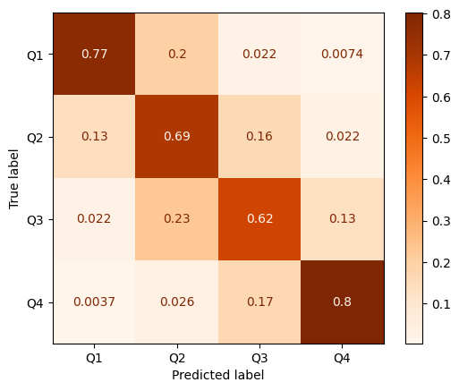

```
[[209  53   6   2]
 [ 36 183  42   6]
 [  6  62 169  35]
 [  1   7  45 215]]
              precision    recall  f1-score   support

          Q1       0.83      0.77      0.80       270
          Q2       0.60      0.69      0.64       267
          Q3       0.65      0.62      0.63       272
          Q4       0.83      0.80      0.82       268

    accuracy                           0.72      1077
   macro avg       0.73      0.72      0.72      1077
weighted avg       0.73      0.72      0.72      1077
```

```python
svcbm = grid_search.best_estimator_
svc_y_pred = svcbm.predict(X_test)
svcacc = accuracy_score(svc_y_pred, y_test)
print(f"Accuracy: {svcacc:.4f}")
ConfusionMatrixDisplay.from_estimator(svcbm, X_test, y_test, cmap = plt.cm.Oranges, normalize = 'true')
plt.show()
print(confusion_matrix(y_test, svc_y_pred))
print(classification_report(y_test, svc_y_pred))
```

## Random Forest Classifier

For the Random Forest Classifier, using too many hyperparameters with GridSearchCV will become too computationally expensive for my server to handle, even with the use of a GPU. Multiple hyperparameters are set to standards that I have judged to be suited for the analysis' needs. Leaving the number of trees constant and depth ambiguous should be fine, so long as the splits and leaves of each tree can be customized. At 70% accuracy, this test is slightly less accurate at prediction than the SVC model, but it is more accurate at predicting values in the third quartile.

```python
start = time.time()
rf = RandomForestClassifier(max_depth = None, n_estimators = 500, criterion = 'gini', max_features = 'sqrt', bootstrap = False, random_state = 1)
param_grid = {
    'min_samples_split': [2, 5, 10],
    'min_samples_leaf': [1, 2, 4]
}
grid_search = GridSearchCV(rf, param_grid, cv=5, scoring='accuracy')
grid_search.fit(X_train, y_train)
best_params = grid_search.best_params_
print("Best Hyperparameters:", best_params)
end = time.time()
print(f"Time elapsed: {end-start:.4f}")
```

```
Best Hyperparameters: {'min_samples_leaf': 1, 'min_samples_split': 2}
Time elapsed: 218.1307
```

```
Accuracy: 0.7029
```

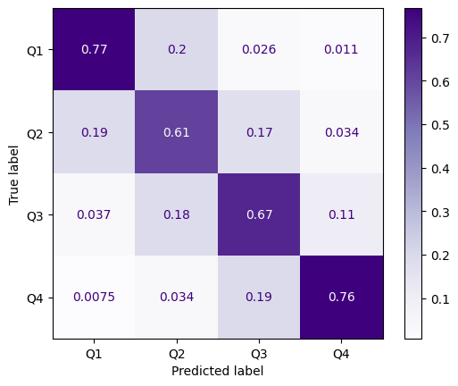

```
[[207  53   7   3]
 [ 50 162  46   9]
 [ 10  50 183  29]
 [  2   9  52 205]]
              precision    recall  f1-score   support

          Q1       0.77      0.77      0.77       270
          Q2       0.59      0.61      0.60       267
          Q3       0.64      0.67      0.65       272
          Q4       0.83      0.76      0.80       268

    accuracy                           0.70      1077
   macro avg       0.71      0.70      0.70      1077
weighted avg       0.71      0.70      0.70      1077
```

```python
rfbm = grid_search.best_estimator_
rf_y_pred = rfbm.predict(X_test)
rfacc = accuracy_score(rf_y_pred, y_test)
print(f"Accuracy: {rfacc:.4f}")
ConfusionMatrixDisplay.from_estimator(rfbm, X_test, y_test, cmap = plt.cm.Purples, normalize = 'true')
plt.show()
print(confusion_matrix(y_test, rf_y_pred))
print(classification_report(y_test, rf_y_pred))
```

```
<function matplotlib.pyplot.show(close=None, block=None)>
```

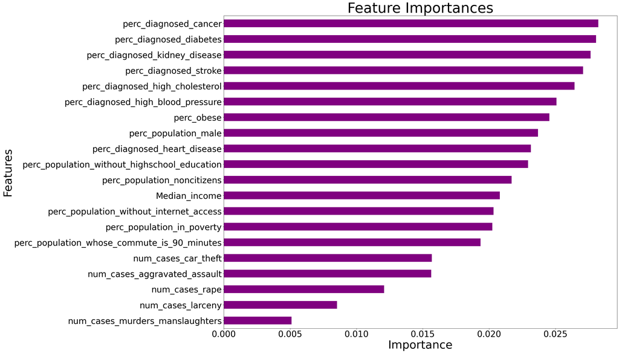

```python
importances = pd.Series(data = rfbm.feature_importances_,
                        index = X_train.columns)

importances_sorted = importances.sort_values()
importances_sorted = importances_sorted.head(20)

fig = plt.figure(figsize = (25,20))
ax = importances_sorted.plot(kind='barh', color='purple')
plt.title('Feature Importances', fontsize=50)  # Title font size
plt.xlabel('Importance', fontsize=40)  # X-axis label font size
plt.ylabel('Features', fontsize=40)  # Y-axis label font size
ax.tick_params(axis='x', labelsize=30)  # X-axis tick label size
ax.tick_params(axis='y', labelsize=30)
plt.show
```

```python
missX = miss_data.drop(['Unnamed: 0', 'spatial_id', 'name', 'perc_population_with_depression'], axis=1)
missX_scaled = scaler.fit_transform(missX)
missX = pd.DataFrame(missX_scaled, columns=missX.columns)
```

```python
def predmatcher(model):
    x = list(model.predict(missX_scaled))
    namedpreds = []
    for i in range(0, len(x)):
        namedpreds.append(x[i])
    return namedpreds
```

```python
modelpreds = pd.DataFrame({
    'County_Name':list(miss_data.name),
    f'logregpreds':predmatcher(logregbm),
    f'ldapreds':predmatcher(ldabm),
#     f'NBpreds':predmatcher(NBayes),
    f'knn':predmatcher(knn),
    f'svcpreds':predmatcher(svcbm),
    f'rfpreds':predmatcher(rfbm)
    })
for i in ['Q1', 'Q2', 'Q3', 'Q4']:
    modelpreds[f'{i}_counts'] = modelpreds.apply(lambda row: (row == i).sum(), axis=1)
modelpreds['max'] = modelpreds[['Q1_counts', 'Q2_counts', 'Q3_counts', 'Q4_counts']].max(axis=1)
modelpreds['consensus'] = modelpreds.mode(axis=1)[0]
modelpreds['consensus'] = modelpreds['consensus'].replace(2, 'Tie')
modelpredsFL = modelpreds[modelpreds['County_Name'].str.contains('FL')]
```

```python
votedf = pd.DataFrame({
    f'logregpreds':lr_y_pred,
    f'ldapreds':lda_y_pred,
    f'knn':knn_y_pred,
    f'svcpreds':svc_y_pred,
    f'rfpreds':rf_y_pred
    })
for i in ['Q1', 'Q2', 'Q3', 'Q4']:
    votedf[f'{i}_counts'] = votedf.apply(lambda row: (row == i).sum(), axis=1)
votedf['max'] = votedf[['Q1_counts', 'Q2_counts', 'Q3_counts', 'Q4_counts']].max(axis=1)
votedf['consensus'] = votedf.mode(axis=1)[0]
votedf['consensus'] = votedf['consensus'].replace(2, 'Q2')
```

```
Accuracy: 0.7000928505106778
```

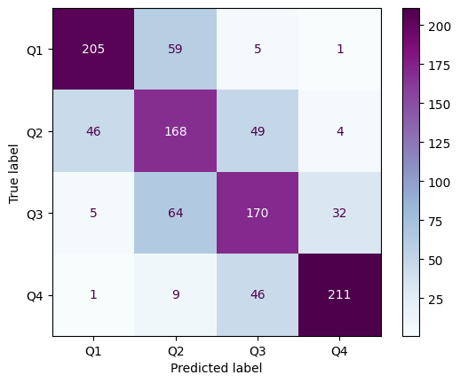

```python
cm = confusion_matrix(list(y_test), list(votedf['consensus']), labels=['Q1', 'Q2', 'Q3', 'Q4'])
disp = ConfusionMatrixDisplay(confusion_matrix=cm, display_labels=['Q1', 'Q2', 'Q3', 'Q4'])
disp.plot(cmap=plt.cm.BuPu)
accuracy = accuracy_score(list(y_test), list(votedf['consensus']))
print(f"Accuracy: {accuracy}")
plt.show()
```

## Analyzing Results

For Floridian counties, the SVC - the most accurate model - predicts an overwhelming majority in the the second quartile, and six counties in the first quartile. This means that, overall, most Floridian counties should have lower rates of depression than the rest of the country, with a few in particular - Lee, Orange, Palm Beach, Hillsborough, Miami, and Escambia - having exceptionally low rates of depresssion.

However, the RF model, which had a higher accuracy for detecting counties in the 3rd quartile, tells a different story. It predicts the majority of counties as belonging to the 3rd quartile, with just three belonging to the 2nd quartile. This is an entirely new set of predictions created from the differences between the two models.

The consensus column, which factors in the predictions of all the models I have covered thus far (save for the Naive Bayes), predicts most counties being in the third quartile, some in the second, one tie between the third and second, and one county in the first, that being Miami.

```python
modelpredsFL.head()
```

|  | County_Name | logregpreds | ldapreds | knn | svcpreds | rfpreds | Q1_counts | Q2_counts | Q3_counts | Q4_counts | max | consensus |
| --- | --- | --- | --- | --- | --- | --- | --- | --- | --- | --- | --- | --- |
| 77 | Union County, FL | Q2 | Q2 | Q2 | Q2 | Q3 | 0 | 4 | 1 | 0 | 4 | Q2 |
| 78 | Gilchrist County, FL | Q3 | Q2 | Q3 | Q2 | Q3 | 0 | 2 | 3 | 0 | 3 | Q3 |
| 79 | Seminole County, FL | Q3 | Q3 | Q3 | Q2 | Q3 | 0 | 1 | 4 | 0 | 4 | Q3 |
| 80 | Hardee County, FL | Q2 | Q2 | Q3 | Q2 | Q3 | 0 | 3 | 2 | 0 | 3 | Q2 |
| 81 | DeSoto County, FL | Q3 | Q2 | Q3 | Q2 | Q3 | 0 | 2 | 3 | 0 | 3 | Q3 |

```python
modelpredsFL['svcpreds'].value_counts()
```

```
svcpreds
Q2    61
Q1     6
Name: count, dtype: int64
```

```python
modelpredsFLQ1 = modelpredsFL[modelpredsFL['svcpreds'] == 'Q1']
modelpredsFLQ1.head(6)
```

|  | County_Name | logregpreds | ldapreds | knn | svcpreds | rfpreds | Q1_counts | Q2_counts | Q3_counts | Q4_counts | max | consensus |
| --- | --- | --- | --- | --- | --- | --- | --- | --- | --- | --- | --- | --- |
| 115 | Lee County, FL | Q3 | Q3 | Q3 | Q1 | Q3 | 1 | 0 | 4 | 0 | 4 | Q3 |
| 122 | Orange County, FL | Q3 | Q3 | Q1 | Q1 | Q3 | 2 | 0 | 3 | 0 | 3 | Q3 |
| 129 | Palm Beach County, FL | Q4 | Q3 | Q3 | Q1 | Q3 | 1 | 0 | 3 | 1 | 3 | Q3 |
| 131 | Hillsborough County, FL | Q3 | Q3 | Q3 | Q1 | Q3 | 1 | 0 | 4 | 0 | 4 | Q3 |
| 141 | Miami-Dade County, FL | Q1 | Q3 | Q1 | Q1 | Q3 | 3 | 0 | 2 | 0 | 3 | Q1 |
| 143 | Escambia County, FL | Q3 | Q2 | Q3 | Q1 | Q3 | 1 | 1 | 3 | 0 | 3 | Q3 |

```python
modelpredsFL['rfpreds'].value_counts()
```

```
rfpreds
Q3    64
Q2     3
Name: count, dtype: int64
```

```python
modelpredsFLQ2 = modelpredsFL[modelpredsFL['rfpreds'] == 'Q2']
modelpredsFLQ2.head()
```

|  | County_Name | logregpreds | ldapreds | knn | svcpreds | rfpreds | Q1_counts | Q2_counts | Q3_counts | Q4_counts | max | consensus |
| --- | --- | --- | --- | --- | --- | --- | --- | --- | --- | --- | --- | --- |
| 93 | Gadsden County, FL | Q3 | Q3 | Q2 | Q2 | Q2 | 0 | 3 | 2 | 0 | 3 | Q2 |
| 95 | Madison County, FL | Q2 | Q2 | Q3 | Q2 | Q2 | 0 | 4 | 1 | 0 | 4 | Q2 |
| 104 | Hamilton County, FL | Q2 | Q2 | Q3 | Q2 | Q2 | 0 | 4 | 1 | 0 | 4 | Q2 |

```python
modelpredsFL['consensus'].value_counts()
```

```
consensus
Q3     49
Q2     16
Tie     1
Q1      1
Name: count, dtype: int64
```

```python
modelpredsFLQ1 = modelpredsFL[modelpredsFL['consensus'] == 'Q1']
modelpredsFLQ1.head()
```

|  | County_Name | logregpreds | ldapreds | knn | svcpreds | rfpreds | Q1_counts | Q2_counts | Q3_counts | Q4_counts | max | consensus |
| --- | --- | --- | --- | --- | --- | --- | --- | --- | --- | --- | --- | --- |
| 141 | Miami-Dade County, FL | Q1 | Q3 | Q1 | Q1 | Q3 | 3 | 0 | 2 | 0 | 3 | Q1 |

```python
modelpredsFLTie = modelpredsFL[modelpredsFL['consensus'] == 'Tie']
modelpredsFLTie.head()
```

|  | County_Name | logregpreds | ldapreds | knn | svcpreds | rfpreds | Q1_counts | Q2_counts | Q3_counts | Q4_counts | max | consensus |
| --- | --- | --- | --- | --- | --- | --- | --- | --- | --- | --- | --- | --- |
| 125 | Hendry County, FL | Q4 | Q3 | Q2 | Q2 | Q3 | 0 | 2 | 2 | 1 | 2 | Tie |

## Conclusion

In battling growing rates of depression across the country, it is important to understand the impact of county-specific circumstances, cultures, demographics, and more. Perhaps, based on the results of this prediction, research on depression in Florida can start with Miami to see if there are special qualities about the county that explain why it is predicted to have minimal depression rates as opposed to the rest of the state. From there, an empirically supported approach to supporting mental health in Florida can be achieved.